# Act Report - WeRateDogs Twitter Data Archive

## We Rate Dogs Data

The WeRateDogs Twitter archive contains basic tweet data for all 5000+ of their tweets, but not everything. One column the archive does contain though: each tweet's text, which I used to extract rating, dog name, and dog "stage" (i.e. doggo, floofer, pupper, and puppo) to make this Twitter archive "enhanced." Of the 5000+ tweets, I have filtered for tweets with ratings only (there are 2356) and aslo removed retweets out of the data

## Wrangling Data

I gathered all pieces of required data, assessed visually and programmatically and cleaned them to make sure they are consistent, accurate, complete and valid. Also, I collated each tweet's retweet count and favorite ("like") count at the minimum and any additional data you find interesting. Using the tweet IDs in the WeRateDogs Twitter archive, query the Twitter API for each tweet's JSON data using Python's Tweepy library and store each tweet's entire set of JSON data in a file called tweet_json.txt file.

## Visualization

### Relationship between retweet count and favorite count

From my analysis of the gathered data, I found that there is a strong relationship between the retweet count and favorite count as plotting these two values against each shows a line produced by a tight collection of points as seen in the graph below.

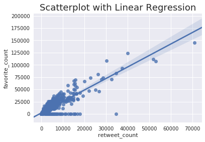

## Insights

### The most popular dog stages over the years

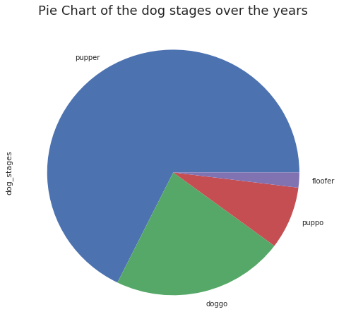

### The years had the most tweets put to the We Rate Dogs twitter profile

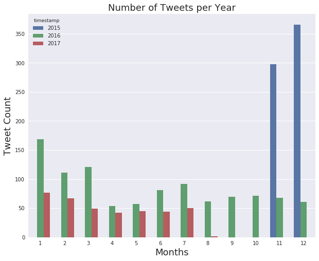

### Thedog name with the most favorite count over the years

As gotten from my analysis of specific fied on the file `twitter_archive_master.csv` in my report, I can see the dog name **Bo** has received the most favorite count on the we rate dogs twitter profile over the years

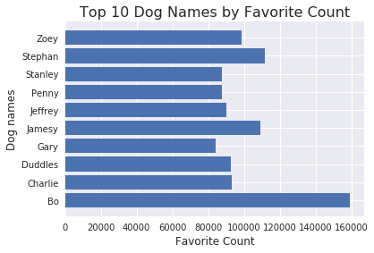